# Analyzing Spatial data from the GoFord bike sharing service

## by Lucas Valério de Oliveira

## Investigation Overview

In this investigation we will look for the spatial distributions of bike stations and understand the relationship between the time variables, duration of trips and urban mobility between Macro and Micro regions established by means of cauterization method K Means.

## Starting point

It was necessary to evaluate whether the trips had consistent latitude and longitude data and this was possible to verify by plotting the point dispersion plots with the coordinate axes being latitude and longitude, respectively. We can note that by the distribution obtained there is a great consistency of spatial information and they seem to have well-defined regions in space that can be used to differentiate characteristics between regions

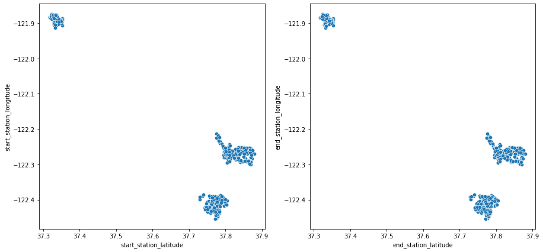

```python
f, ax = plt.subplots(1,2,figsize=(15,7))
plot_start = sns.scatterplot(ax=ax[0],data=master_df,x='start_station_latitude',y='start_station_longitude');
plot_end = sns.scatterplot(ax=ax[1],data=master_df,x='end_station_latitude',y='end_station_longitude');
```

## Need to group by regions

Geographic data alone would not add much to the data analysis, since we should know one thing in common between them and the only information we knew was the name of the bike stations. For this, a grouping function was used through the K-Mean clustering model that seeks to assign a common centroide among the number of predefined groups.

### Delimitation of Study Groups

Two approaches have been defined:

1. Macro regions (3 Clusters)
2. Micro regions (6 Cluesters)

## Macro Regions

The macro regions were well defined in groups that already had aspects of isolation. This will provide the basis for the studies and will serve to compare with the micro regions.

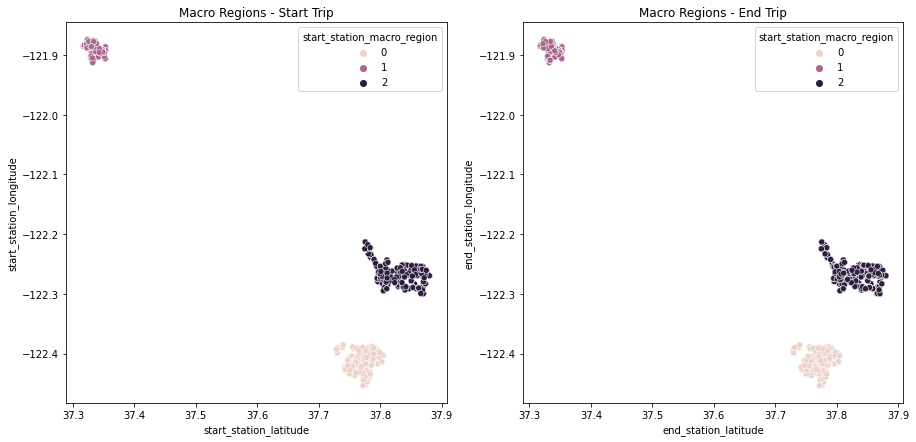

```python
f, ax = plt.subplots(1,2,figsize=(15,7))
plot_start = sns.scatterplot(ax=ax[0],data=master_df,
                             x='start_station_latitude',y='start_station_longitude', hue="start_station_macro_region");

plot_end = sns.scatterplot(ax=ax[1],data=master_df,
                           x='end_station_latitude',y='end_station_longitude', hue="start_station_macro_region");
ax[0].set_title('Macro Regions - Start Trip');
ax[1].set_title('Macro Regions - End Trip');
```

### Micro Regions

The micro regions were divided into 6 clusters, we can see that the macro regions of the lower part were left with clusters in the region of the extreme southeast and 2 clusters in the region just above, finally the last micro region was located in the entire portion of the macro region located in the northwest part of the graph.

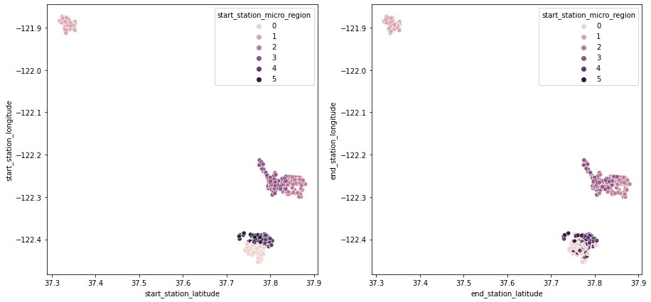

```python
f, ax = plt.subplots(1,2,figsize=(15,7))
plot_start = sns.scatterplot(ax=ax[0],data=master_df,
                             x='start_station_latitude',y='start_station_longitude', hue="start_station_micro_region");

plot_end = sns.scatterplot(ax=ax[1],data=master_df,
                           x='end_station_latitude',y='end_station_longitude', hue="start_station_micro_region");
```

# Macro Region 0

#### Questions:

The results show that the people in the center of region 0 have long displacements in the peripheries of the region, evidenced by the first graph and short displacements in the centers.

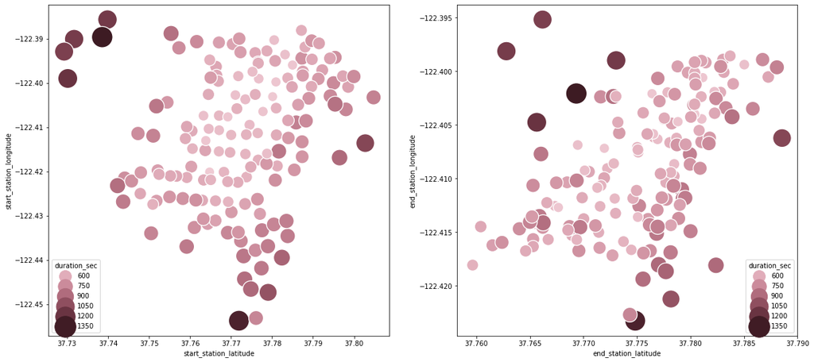

```python
macro0 = master_df[master_df['start_station_macro_region'] == 0].groupby('start_station_name').mean()
plt.figure(figsize = [20, 20]);
ax= plt.subplot(2, 2, 1);
sns.scatterplot(x="start_station_latitude", y="start_station_longitude",hue='duration_sec',
                   size='duration_sec', sizes=(200, 1000) ,data=macro0,palette = 'ch:s=0.8,rot=0')
ax = plt.subplot(2, 2, 2);
sns.scatterplot(x="end_station_latitude", y="end_station_longitude",hue='duration_sec',
                   size='duration_sec', sizes=(200, 1000) ,data=macro0,palette = 'ch:s=0.8,rot=0');
```

Graph two shows that the short displacements made in the region are widely used both by the morning and in the afternoon, while in the peripheries the schedule tends to be used in the morning or in the afternoon, this can be the effect of the people who will perform the task in the central region and at the end of the day returns to their homes.

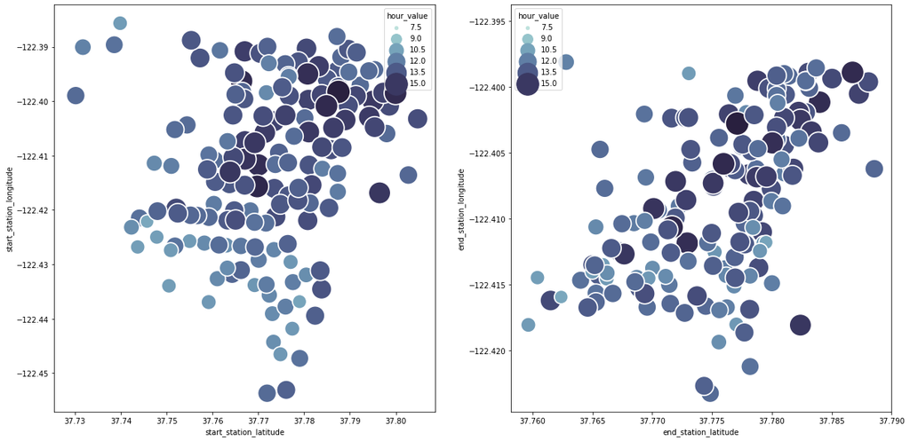

```python
plt.figure(figsize = [20, 10]);
ax= plt.subplot(1, 2, 1);
sns.scatterplot(x="start_station_latitude", y="start_station_longitude",hue='hour_value',
                   size='hour_value', sizes=(0, 1000) ,data=macro0,palette = 'ch:s=.25,rot=-.35')
ax = plt.subplot(1, 2, 2);
sns.scatterplot(x="end_station_latitude", y="end_station_longitude",hue='hour_value',
                   size='hour_value', sizes=(0, 1000) ,data=macro0,palette = 'ch:s=.25,rot=-.35');
```

- **In macro region 0,What is the pattern of displacement of people?**

It is evident the displacement of the green group towards the blue and orange group while those of the blue group move towards orange and green. It is observed that the elements of the orange group do not move so much to the other regions. This demonstrates that the orange region is the point of interest for this macro region.

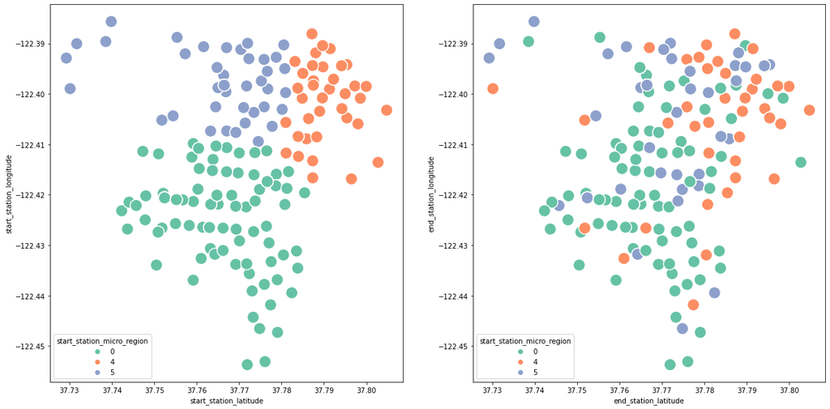

```python
macro0_stations = master_df[master_df['start_station_macro_region'] == 0]
plt.figure(figsize = [20, 10]);
ax= plt.subplot(1, 2, 1);
sns.scatterplot(x="start_station_latitude", y="start_station_longitude",hue='start_station_micro_region',
                    s=300,data=macro0_stations,palette = 'Set2')
ax = plt.subplot(1, 2, 2);
sns.scatterplot(x="end_station_latitude", y="end_station_longitude",hue='start_station_micro_region',
                    s=300,data=macro0_stations,palette = 'Set2');
```

# Macro Region 1

- **In macro region 1, how are spatial data distributed in terms of travel duration?**

The distribution of travel times in the macro region 1 is more uniform than in the other regions, which is evident by the little differentiation of the data. It is observed that there are 2 darker points both at the origin and at the destination indicating that they are points well on the margin in relation to the center of this region.

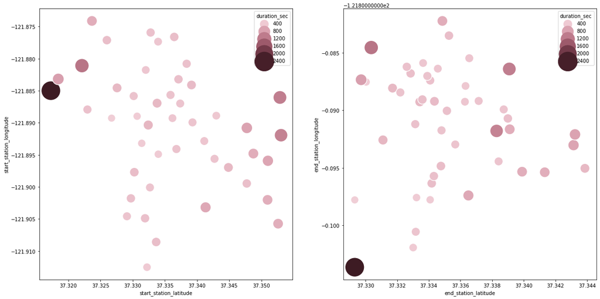

```python
macro1 = master_df[master_df['start_station_macro_region'] == 1].groupby('start_station_name').mean()
plt.figure(figsize = [20, 10]);
ax= plt.subplot(1, 2, 1);
sns.scatterplot(x="start_station_latitude", y="start_station_longitude",hue='duration_sec',
                   size='duration_sec', sizes=(250, 1500) ,data=macro1,palette = 'ch:s=0.8,rot=0')
ax = plt.subplot(1, 2, 2);
sns.scatterplot(x="end_station_latitude", y="end_station_longitude",hue='duration_sec',
                   size='duration_sec', sizes=(250, 1500) ,data=macro1,palette = 'ch:s=0.8,rot=0');
```

- **In macro region 1 relation to the seasons, what is the average time that most people attended?**

There is a great use of the service at the end of the afternoon in the centers and on the margins the greatest use is at the beginning of the day, once again showing that the origin and destination of people are guided by the obligations and daily tasks that revolve around the centers.

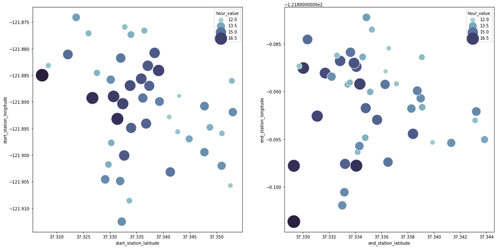

```python
plt.figure(figsize = [20, 10]);
ax= plt.subplot(1, 2, 1);
sns.scatterplot(x="start_station_latitude", y="start_station_longitude",hue='hour_value',
                   size='hour_value', sizes=(0, 1000) ,data=macro1,palette = 'ch:s=.25,rot=-.35')
ax = plt.subplot(1, 2, 2);
sns.scatterplot(x="end_station_latitude", y="end_station_longitude",hue='hour_value',
                   size='hour_value', sizes=(0, 1000) ,data=macro1,palette = 'ch:s=.25,rot=-.35');
```

- **In macro region 1,What is the pattern of displacement of people?**

A curious fact about the displacements of macro region 1 and its micro regions, and that this is a location that there are no subgroups missing in the kmeans method, so all origins are the same as the arrival data. This hinders a deeper analysis of the data and more information about this location needs to be generated.

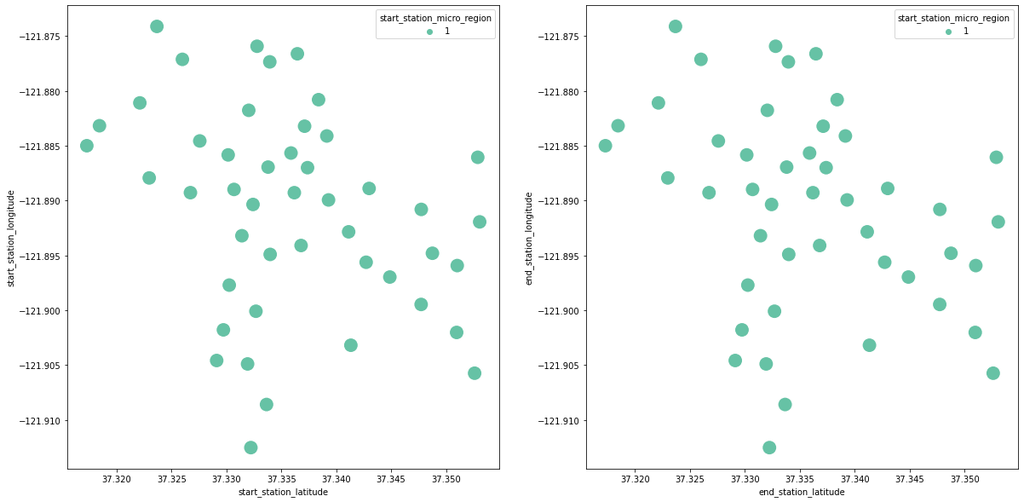

```python
macro1_stations = master_df[master_df['start_station_macro_region'] == 1]
plt.figure(figsize = [20, 10]);
ax= plt.subplot(1, 2, 1);
sns.scatterplot(x="start_station_latitude", y="start_station_longitude",hue='start_station_micro_region',
                    s=300,data=macro1_stations,palette = 'Set2')
ax = plt.subplot(1, 2, 2);
sns.scatterplot(x="end_station_latitude", y="end_station_longitude",hue='start_station_micro_region',
                    s=300,data=macro1_stations,palette = 'Set2');
```

# Macro Region 2

- **In macro region 2, how are spatial data distributed in terms of travel duration?**

Two opposing regions are quite distant from each other and demonstrate longer travel times, while the central region of the data shows a trend of shorter travel times.

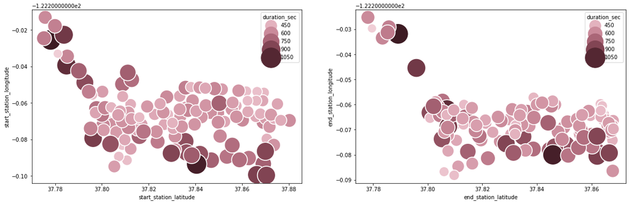

```python
macro2 = master_df[master_df['start_station_macro_region'] == 2].groupby('start_station_name').mean()
plt.figure(figsize = [20, 6]);
ax= plt.subplot(1, 2, 1);
sns.scatterplot(x="start_station_latitude", y="start_station_longitude",hue='duration_sec',
                   size='duration_sec', sizes=(300, 1500) ,data=macro2,palette = 'ch:s=0.8,rot=0')
ax = plt.subplot(1, 2, 2);
sns.scatterplot(x="end_station_latitude", y="end_station_longitude",hue='duration_sec',
                   size='duration_sec', sizes=(300, 1500) ,data=macro2,palette = 'ch:s=0.8,rot=0');
```

- **In macro region 2 relation to the seasons, what is the average time that most people attended?**

This is one of the largest macro regions of the study and its micro regions show a great displacement relationship between them. There are several points where we can find high utilization both in the morning and in the afternoon. However, a point further to the west center of the graph shows a large concentration of average usage time both at the beginning of the day and at the end of the day. This shows that this is a location that receives more people during the time variation.

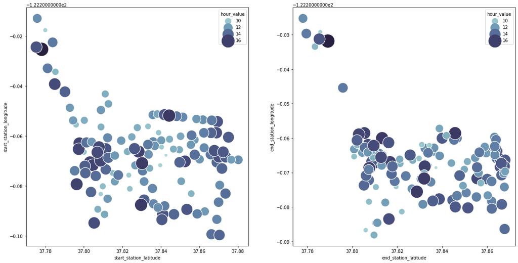

```python
plt.figure(figsize = [20, 10]);
ax= plt.subplot(1, 2, 1);
sns.scatterplot(x="start_station_latitude", y="start_station_longitude",hue='hour_value',
                   size='hour_value', sizes=(0, 1000) ,data=macro2,palette = 'ch:s=.25,rot=-.35')
ax = plt.subplot(1, 2, 2);
sns.scatterplot(x="end_station_latitude", y="end_station_longitude",hue='hour_value',
                   size='hour_value', sizes=(0, 1000) ,data=macro2,palette = 'ch:s=.25,rot=-.35');
```

- **In macro region 2,What is the pattern of displacement of people?**

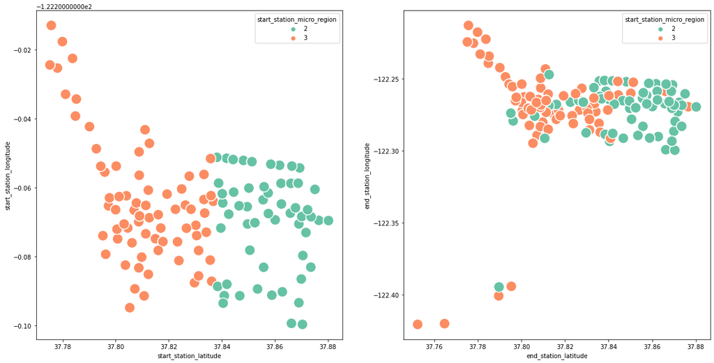

```python
macro2_stations = master_df[master_df['start_station_macro_region'] == 2]
plt.figure(figsize = [20, 10]);
ax= plt.subplot(1, 2, 1);
sns.scatterplot(x="start_station_latitude", y="start_station_longitude",hue='start_station_micro_region',
                    s=300,data=macro2_stations,palette = 'Set2')
ax = plt.subplot(1, 2, 2);
sns.scatterplot(x="end_station_latitude", y="end_station_longitude",hue='start_station_micro_region',
                    s=300,data=macro2_stations,palette = 'Set2');
```

## References

https://jakevdp.github.io/PythonDataScienceHandbook/04.13-geographic-data-with-basemap.html https://geopy.readthedocs.io/en/stable/index.html?highlight=latitude#geopy.location.Location.latitude https://scikit-learn.org/stable/modules/generated/sklearn.cluster.KMeans.html https://plotly.com/python/scattermapbox/ https://www.geeksforgeeks.org/get-the-city-state-and-country-names-from-latitude-and-longitude-using-python/